# Fitness Tracker - A project in R

## Business task

- Identify trends in smart device usage at competitor companies
- Apply trends in smart device usage to bellabeat customers
- Produce high level recommendations for bellabeat marketing strategy

## Data source

The project uses FitBit Fitness Tracker Dataset on Kaggle, made available through Mobius

#### Details:

- 30 FitBit users consented to tracking as part of distributed survey via Amazon Mechanical Turk for a month period in 2016
- The dataset includes 18 csv files containing: daily calories, steps, activity intensity and sleep; hourly calories, intensities and steps; minutely calories, intensities, METs, sleep and steps; user inputted weight data
- The dataset is open source and all participants consented to their data being used

#### Considerations

- Metadata from Kaggle was missing but has been located
- Sample size is 30 people over 1 month. This questions the validity of any generalisations about trends in the data
- Metadata from kaggle state 30 users, original study states 35, dataset contains 33
- There is no information about the 30 participants, meaning the data is likely to be biased

# Analysis

## Install packages

```r
install.packages("tidyverse")
install.packages("janitor")
install.packages("readr")
install.packages("plyr")
install.packages("lubridate")
```

```
Error in install.packages : Updating loaded packages
```

```r
install.packages("ggplot2")
```

```
Error in install.packages : Updating loaded packages
```

```r
install.packages("dplyr")
```

```
Error in install.packages : Updating loaded packages
```

```r
install.packages("Hmisc")
install.packages("corrplot")
install.packages("tidyr")
library(tidyverse)
library(janitor)
library(readr)
library(plyr)
library(lubridate)
library(ggplot2)
library(dplyr)
library(Hmisc)
library(corrplot)
library(tidyr)
```

## Read in data from csv

```r
daily_activity <- read_csv("C:/Users/katba/Data analysis learning/Portfolio/BellabeatCaseStudy/Fitabase Data 4.12.16-5.12.16/dailyActivity_merged.csv")
daily_sleep <- read_csv("C:/Users/katba/Data analysis learning/Portfolio/BellabeatCaseStudy/Fitabase Data 4.12.16-5.12.16/sleepDay_merged.csv")
hourly_calories <- read_csv("C:/Users/katba/Data analysis learning/Portfolio/BellabeatCaseStudy/Fitabase Data 4.12.16-5.12.16/hourlyCalories_merged.csv")
hourly_intensity <- read_csv("C:/Users/katba/Data analysis learning/Portfolio/BellabeatCaseStudy/Fitabase Data 4.12.16-5.12.16/hourlyIntensities_merged.csv")
hourly_steps <- read_csv("C:/Users/katba/Data analysis learning/Portfolio/BellabeatCaseStudy/Fitabase Data 4.12.16-5.12.16/hourlySteps_merged.csv")
weight <- read_csv("C:/Users/katba/Data analysis learning/Portfolio/BellabeatCaseStudy/Fitabase Data 4.12.16-5.12.16/weightLogInfo_merged.csv")
```

## Explore daily dataframes

```r
head(daily_activity)
```

| Id | ActivityDate | TotalSteps | TotalDistance | TrackerDistance | LoggedActivitiesDistance | VeryActiveDistance | ModeratelyActiveDistance | LightActiveDistance | SedentaryActiveDistance | VeryActiveMinutes | FairlyActiveMinutes | LightlyActiveMinutes | SedentaryMinutes | Calories |
| --- | --- | --- | --- | --- | --- | --- | --- | --- | --- | --- | --- | --- | --- | --- |
| 1503960366 | 4/12/2016 | 13162 | 8.50 | 8.50 | 0 | 1.88 | 0.55 | 6.06 | 0 | 25 | 13 | 328 | 728 | 1985 |
| 1503960366 | 4/13/2016 | 10735 | 6.97 | 6.97 | 0 | 1.57 | 0.69 | 4.71 | 0 | 21 | 19 | 217 | 776 | 1797 |
| 1503960366 | 4/14/2016 | 10460 | 6.74 | 6.74 | 0 | 2.44 | 0.40 | 3.91 | 0 | 30 | 11 | 181 | 1218 | 1776 |
| 1503960366 | 4/15/2016 | 9762 | 6.28 | 6.28 | 0 | 2.14 | 1.26 | 2.83 | 0 | 29 | 34 | 209 | 726 | 1745 |
| 1503960366 | 4/16/2016 | 12669 | 8.16 | 8.16 | 0 | 2.71 | 0.41 | 5.04 | 0 | 36 | 10 | 221 | 773 | 1863 |
| 1503960366 | 4/17/2016 | 9705 | 6.48 | 6.48 | 0 | 3.19 | 0.78 | 2.51 | 0 | 38 | 20 | 164 | 539 | 1728 |

```r
head(daily_sleep)
```

| Id | SleepDay | TotalSleepRecords | TotalMinutesAsleep | TotalTimeInBed |
| --- | --- | --- | --- | --- |
| 1503960366 | 4/12/2016 12:00:00 AM | 1 | 327 | 346 |
| 1503960366 | 4/13/2016 12:00:00 AM | 2 | 384 | 407 |
| 1503960366 | 4/15/2016 12:00:00 AM | 1 | 412 | 442 |
| 1503960366 | 4/16/2016 12:00:00 AM | 2 | 340 | 367 |
| 1503960366 | 4/17/2016 12:00:00 AM | 1 | 700 | 712 |
| 1503960366 | 4/19/2016 12:00:00 AM | 1 | 304 | 320 |

```r
str(daily_activity)
```

```
spc_tbl_ [940 × 15] (S3: spec_tbl_df/tbl_df/tbl/data.frame)
 $ Id                      : num [1:940] 1.5e+09 1.5e+09 1.5e+09 1.5e+09 1.5e+09 ...
 $ ActivityDate            : chr [1:940] "4/12/2016" "4/13/2016" "4/14/2016" "4/15/2016" ...
 $ TotalSteps              : num [1:940] 13162 10735 10460 9762 12669 ...
 $ TotalDistance           : num [1:940] 8.5 6.97 6.74 6.28 8.16 ...
 $ TrackerDistance         : num [1:940] 8.5 6.97 6.74 6.28 8.16 ...
 $ LoggedActivitiesDistance: num [1:940] 0 0 0 0 0 0 0 0 0 0 ...
 $ VeryActiveDistance      : num [1:940] 1.88 1.57 2.44 2.14 2.71 ...
 $ ModeratelyActiveDistance: num [1:940] 0.55 0.69 0.4 1.26 0.41 ...
 $ LightActiveDistance     : num [1:940] 6.06 4.71 3.91 2.83 5.04 ...
 $ SedentaryActiveDistance : num [1:940] 0 0 0 0 0 0 0 0 0 0 ...
 $ VeryActiveMinutes       : num [1:940] 25 21 30 29 36 38 42 50 28 19 ...
 $ FairlyActiveMinutes     : num [1:940] 13 19 11 34 10 20 16 31 12 8 ...
 $ LightlyActiveMinutes    : num [1:940] 328 217 181 209 221 164 233 264 205 211 ...
 $ SedentaryMinutes        : num [1:940] 728 776 1218 726 773 ...
 $ Calories                : num [1:940] 1985 1797 1776 1745 1863 ...
 - attr(*, "spec")=
  .. cols(
  ..   Id = col_double(),
  ..   ActivityDate = col_character(),
  ..   TotalSteps = col_double(),
  ..   TotalDistance = col_double(),
  ..   TrackerDistance = col_double(),
  ..   LoggedActivitiesDistance = col_double(),
  ..   VeryActiveDistance = col_double(),
  ..   ModeratelyActiveDistance = col_double(),
  ..   LightActiveDistance = col_double(),
  ..   SedentaryActiveDistance = col_double(),
  ..   VeryActiveMinutes = col_double(),
  ..   FairlyActiveMinutes = col_double(),
  ..   LightlyActiveMinutes = col_double(),
  ..   SedentaryMinutes = col_double(),
  ..   Calories = col_double()
  .. )
 - attr(*, "problems")=<externalptr>
```

```r
str(daily_sleep)
```

```
spc_tbl_ [413 × 5] (S3: spec_tbl_df/tbl_df/tbl/data.frame)
 $ Id                : num [1:413] 1.5e+09 1.5e+09 1.5e+09 1.5e+09 1.5e+09 ...
 $ SleepDay          : chr [1:413] "4/12/2016 12:00:00 AM" "4/13/2016 12:00:00 AM" "4/15/2016 12:00:00 AM" "4/16/2016 12:00:00 AM" ...
 $ TotalSleepRecords : num [1:413] 1 2 1 2 1 1 1 1 1 1 ...
 $ TotalMinutesAsleep: num [1:413] 327 384 412 340 700 304 360 325 361 430 ...
 $ TotalTimeInBed    : num [1:413] 346 407 442 367 712 320 377 364 384 449 ...
 - attr(*, "spec")=
  .. cols(
  ..   Id = col_double(),
  ..   SleepDay = col_character(),
  ..   TotalSleepRecords = col_double(),
  ..   TotalMinutesAsleep = col_double(),
  ..   TotalTimeInBed = col_double()
  .. )
 - attr(*, "problems")=<externalptr>
```

## Prepare daily dataframes to join

```r
daily_activity_clean <- daily_activity %>%
  mutate(ActivityDate= as.Date(ActivityDate, format="%m/%d/%Y"))

daily_sleep_clean <- daily_sleep %>%
  mutate(SleepDay= as.Date(SleepDay, format="%m/%d/%Y %H:%M:%S"))

daily_sleep_clean <- clean_names(daily_sleep_clean)
daily_activity_clean <- clean_names(daily_activity_clean)

daily_activity_clean <- rename(daily_activity_clean, date=activity_date)
daily_sleep_clean <- rename(daily_sleep_clean, date=sleep_day)
```

## Join daily dataframes

```r
daily <- full_join(daily_activity_clean, daily_sleep_clean, by = c("id", "date"))
```

### Additional join with weight

```r
weight_clean <- clean_names(weight)
weight_clean <- weight_clean %>%
  mutate(date= as.Date(date, format="%m/%d/%Y %H:%M:%S"))
daily_all <- full_join(daily, weight_clean, by= c("id", "date"))
```

## Clean ‘daily’ data

### Review datatypes, min and max values

```r
summary(daily_all)
```

```
       id                 date             total_steps    total_distance   tracker_distance logged_activities_distance very_active_distance moderately_active_distance light_active_distance sedentary_active_distance
 Min.   :1.504e+09   Min.   :2016-04-12   Min.   :    0   Min.   : 0.000   Min.   : 0.000   Min.   :0.000              Min.   : 0.000       Min.   :0.0000             Min.   : 0.000        Min.   :0.000000
 1st Qu.:2.320e+09   1st Qu.:2016-04-19   1st Qu.: 3795   1st Qu.: 2.620   1st Qu.: 2.620   1st Qu.:0.000              1st Qu.: 0.000       1st Qu.:0.0000             1st Qu.: 1.950        1st Qu.:0.000000
 Median :4.445e+09   Median :2016-04-26   Median : 7439   Median : 5.260   Median : 5.260   Median :0.000              Median : 0.220       Median :0.2400             Median : 3.380        Median :0.000000
 Mean   :4.858e+09   Mean   :2016-04-26   Mean   : 7652   Mean   : 5.503   Mean   : 5.489   Mean   :0.110              Mean   : 1.504       Mean   :0.5709             Mean   : 3.349        Mean   :0.001601
 3rd Qu.:6.962e+09   3rd Qu.:2016-05-04   3rd Qu.:10734   3rd Qu.: 7.720   3rd Qu.: 7.715   3rd Qu.:0.000              3rd Qu.: 2.065       3rd Qu.:0.8050             3rd Qu.: 4.790        3rd Qu.:0.000000
 Max.   :8.878e+09   Max.   :2016-05-12   Max.   :36019   Max.   :28.030   Max.   :28.030   Max.   :4.942              Max.   :21.920       Max.   :6.4800             Max.   :10.710        Max.   :0.110000

 very_active_minutes fairly_active_minutes lightly_active_minutes sedentary_minutes    calories    total_sleep_records total_minutes_asleep total_time_in_bed   weight_kg      weight_pounds        fat
 Min.   :  0.00      Min.   :  0.00        Min.   :  0            Min.   :   0.0    Min.   :   0   Min.   :1.000       Min.   : 58.0        Min.   : 61.0     Min.   : 52.60   Min.   :116.0   Min.   :22.00
 1st Qu.:  0.00      1st Qu.:  0.00        1st Qu.:127            1st Qu.: 729.0    1st Qu.:1830   1st Qu.:1.000       1st Qu.:361.0        1st Qu.:403.0     1st Qu.: 61.40   1st Qu.:135.4   1st Qu.:22.75
 Median :  4.00      Median :  7.00        Median :199            Median :1057.0    Median :2140   Median :1.000       Median :433.0        Median :463.0     Median : 62.50   Median :137.8   Median :23.50
 Mean   : 21.24      Mean   : 13.63        Mean   :193            Mean   : 990.4    Mean   :2308   Mean   :1.119       Mean   :419.5        Mean   :458.6     Mean   : 72.04   Mean   :158.8   Mean   :23.50
 3rd Qu.: 32.00      3rd Qu.: 19.00        3rd Qu.:264            3rd Qu.:1229.0    3rd Qu.:2796   3rd Qu.:1.000       3rd Qu.:490.0        3rd Qu.:526.0     3rd Qu.: 85.05   3rd Qu.:187.5   3rd Qu.:24.25
 Max.   :210.00      Max.   :143.00        Max.   :518            Max.   :1440.0    Max.   :4900   Max.   :3.000       Max.   :796.0        Max.   :961.0     Max.   :133.50   Max.   :294.3   Max.   :25.00
                                                                                                   NA's   :530         NA's   :530          NA's   :530       NA's   :876      NA's   :876     NA's   :941
      bmi        is_manual_report     log_id
 Min.   :21.45   Mode :logical    Min.   :1.460e+12
 1st Qu.:23.96   FALSE:26         1st Qu.:1.461e+12
 Median :24.39   TRUE :41         Median :1.462e+12
 Mean   :25.19   NA's :876        Mean   :1.462e+12
 3rd Qu.:25.56                    3rd Qu.:1.462e+12
 Max.   :47.54                    Max.   :1.463e+12
 NA's   :876                      NA's   :876
```

### Rename columns for consistency across dataset

```r
daily_all_clean <- rename(daily_all, total_distance_km=total_distance, tracker_distance_km=tracker_distance,
                          logged_distance_km=logged_activities_distance, very_active_km=very_active_distance,
                          moderate_active_km=moderately_active_distance, light_active_km=light_active_distance,
                          sedentary_active_km=sedentary_active_distance, moderate_active_minutes=fairly_active_minutes,
                          total_minutes_in_bed=total_time_in_bed)
```

### Check for duplicated rows

Remove 3 duplicated rows

```r
sum(duplicated(daily_all_clean))
```

```
[1] 3
```

```r
daily_all_clean <- daily_all_clean[!duplicated(daily_all_clean), ]
```

### Check number of unique ids for number of users

See ‘considerations’ for discussion

```r
length(unique(daily_all_clean$id))
```

```
[1] 33
```

### Check calculated columns

Total_distance is not tracker + logged, and it is also not just tracker for all rows. Unclear how total_distance was calculated, so tracker_distance will be used as primary measure. total_distance_km and total_distance_calc columns dropped.

```r
colnames(daily_all_clean)
```

```
 [1] "id"                      "date"                    "total_steps"             "total_distance_km"       "tracker_distance_km"     "logged_distance_km"      "very_active_km"          "moderate_active_km"
 [9] "light_active_km"         "sedentary_active_km"     "very_active_minutes"     "moderate_active_minutes" "lightly_active_minutes"  "sedentary_minutes"       "calories"                "total_sleep_records"
[17] "total_minutes_asleep"    "total_minutes_in_bed"    "weight_kg"               "weight_pounds"           "fat"                     "bmi"                     "is_manual_report"        "log_id"
```

```r
daily_all_clean <- mutate(daily_all_clean, total_distance_calc=tracker_distance_km + logged_distance_km)
total_check <- ifelse(daily_all_clean$total_distance_km == daily_all_clean$total_distance_calc, "TRUE", "FALSE")
table(total_check)
```

```
total_check
FALSE  TRUE
   32   908
```

```r
daily_all_clean %>%
  filter(total_distance_km!=total_distance_calc) %>%
  arrange(logged_distance_km)
```

| id | date | total_steps | total_distance_km | tracker_distance_km | logged_distance_km | very_active_km | moderate_active_km | light_active_km | sedentary_active_km | very_active_minutes | moderate_active_minutes | lightly_active_minutes | sedentary_minutes | calories | total_sleep_records | total_minutes_asleep | total_minutes_in_bed | weight_kg | weight_pounds | fat | bmi | is_manual_report | log_id | total_distance_calc |
| --- | --- | --- | --- | --- | --- | --- | --- | --- | --- | --- | --- | --- | --- | --- | --- | --- | --- | --- | --- | --- | --- | --- | --- | --- |
| 6775888955 | 2016-04-26 | 7091 | 5.27 | 5.27 | 1.959596 | 3.48 | 0.87 | 0.73 | 0.00 | 42 | 30 | 47 | 1321 | 2584 | NA | NA | NA | NA | NA | NA | NA | NA | NA | 7.229596 |
| 8378563200 | 2016-04-13 | 12386 | 9.82 | 9.82 | 2.092147 | 4.96 | 0.65 | 4.21 | 0.00 | 116 | 14 | 169 | 680 | 4079 | 2 | 447 | 487 | NA | NA | NA | NA | NA | NA | 11.912147 |
| 8378563200 | 2016-04-18 | 13630 | 10.81 | 10.81 | 2.092147 | 5.05 | 0.56 | 5.20 | 0.00 | 117 | 10 | 174 | 720 | 4157 | 1 | 398 | 451 | NA | NA | NA | NA | NA | NA | 12.902148 |
| 8378563200 | 2016-04-20 | 9388 | 7.44 | 7.44 | 2.092147 | 2.23 | 0.44 | 4.78 | 0.00 | 82 | 8 | 169 | 763 | 3787 | 1 | 381 | 409 | NA | NA | NA | NA | NA | NA | 9.532147 |
| 8378563200 | 2016-04-22 | 12200 | 9.67 | 9.67 | 2.092147 | 4.91 | 0.59 | 4.18 | 0.00 | 113 | 12 | 159 | 769 | 4044 | 1 | 441 | 469 | NA | NA | NA | NA | NA | NA | 11.762147 |
| 8378563200 | 2016-04-25 | 12405 | 9.84 | 9.84 | 2.092147 | 5.05 | 0.87 | 3.92 | 0.00 | 117 | 16 | 141 | 692 | 4005 | 1 | 388 | 402 | NA | NA | NA | NA | NA | NA | 11.932147 |
| 8378563200 | 2016-05-02 | 6064 | 4.81 | 4.81 | 2.092147 | 0.63 | 0.17 | 4.01 | 0.00 | 63 | 4 | 142 | 802 | 3491 | 1 | 351 | 385 | NA | NA | NA | NA | NA | NA | 6.902147 |
| 8378563200 | 2016-05-06 | 7045 | 5.59 | 5.59 | 2.092147 | 1.55 | 0.25 | 3.78 | 0.00 | 74 | 5 | 166 | 831 | 3644 | 1 | 323 | 355 | NA | NA | NA | NA | NA | NA | 7.682147 |
| 8378563200 | 2016-05-09 | 8382 | 6.65 | 6.65 | 2.092147 | 1.27 | 0.66 | 4.72 | 0.00 | 71 | 13 | 171 | 772 | 3721 | 1 | 359 | 399 | NA | NA | NA | NA | NA | NA | 8.742147 |
| 8378563200 | 2016-05-11 | 9143 | 7.25 | 7.25 | 2.092147 | 1.39 | 0.59 | 5.27 | 0.00 | 72 | 10 | 184 | 763 | 3788 | 1 | 368 | 387 | NA | NA | NA | NA | NA | NA | 9.342147 |

[output cut: 22 more lines]

```r
total_check2 <- ifelse(daily_all_clean$total_distance_km == daily_all_clean$tracker_distance_km, "TRUE", "FALSE")
table(total_check2)
```

```
total_check2
FALSE  TRUE
   15   925
```

```r
daily_all_clean <- subset(daily_all_clean, select= -c(total_distance_km,total_distance_calc))
```

### Check weight convertions

Check all weight measurements are accurate between kg and pound columns. 0.001 difference accounts for rounding differences in processing and will not impact further analysis.

```r
daily_all_clean <- mutate(daily_all_clean, weight_pounds_calc=weight_kg*2.20462)
daily_all_clean <- mutate(daily_all_clean, weight_pounds_dif= weight_pounds-weight_pounds_calc)
weight_check <- ifelse(daily_all_clean$weight_pounds_dif > 0.001, "TRUE", "FALSE")
table(weight_check)
```

```
weight_check
FALSE
   67
```

## Clean hourly dataframes individually

```r
str(hourly_calories)
```

```
spc_tbl_ [22,099 × 3] (S3: spec_tbl_df/tbl_df/tbl/data.frame)
 $ Id          : num [1:22099] 1.5e+09 1.5e+09 1.5e+09 1.5e+09 1.5e+09 ...
 $ ActivityHour: chr [1:22099] "4/12/2016 12:00:00 AM" "4/12/2016 1:00:00 AM" "4/12/2016 2:00:00 AM" "4/12/2016 3:00:00 AM" ...
 $ Calories    : num [1:22099] 81 61 59 47 48 48 48 47 68 141 ...
 - attr(*, "spec")=
  .. cols(
  ..   Id = col_double(),
  ..   ActivityHour = col_character(),
  ..   Calories = col_double()
  .. )
 - attr(*, "problems")=<externalptr>
```

```r
str(hourly_intensity)
```

```
spc_tbl_ [22,099 × 4] (S3: spec_tbl_df/tbl_df/tbl/data.frame)
 $ Id              : num [1:22099] 1.5e+09 1.5e+09 1.5e+09 1.5e+09 1.5e+09 ...
 $ ActivityHour    : chr [1:22099] "4/12/2016 12:00:00 AM" "4/12/2016 1:00:00 AM" "4/12/2016 2:00:00 AM" "4/12/2016 3:00:00 AM" ...
 $ TotalIntensity  : num [1:22099] 20 8 7 0 0 0 0 0 13 30 ...
 $ AverageIntensity: num [1:22099] 0.333 0.133 0.117 0 0 ...
 - attr(*, "spec")=
  .. cols(
  ..   Id = col_double(),
  ..   ActivityHour = col_character(),
  ..   TotalIntensity = col_double(),
  ..   AverageIntensity = col_double()
  .. )
 - attr(*, "problems")=<externalptr>
```

```r
str(hourly_steps)
```

```
spc_tbl_ [22,099 × 3] (S3: spec_tbl_df/tbl_df/tbl/data.frame)
 $ Id          : num [1:22099] 1.5e+09 1.5e+09 1.5e+09 1.5e+09 1.5e+09 ...
 $ ActivityHour: chr [1:22099] "4/12/2016 12:00:00 AM" "4/12/2016 1:00:00 AM" "4/12/2016 2:00:00 AM" "4/12/2016 3:00:00 AM" ...
 $ StepTotal   : num [1:22099] 373 160 151 0 0 ...
 - attr(*, "spec")=
  .. cols(
  ..   Id = col_double(),
  ..   ActivityHour = col_character(),
  ..   StepTotal = col_double()
  .. )
 - attr(*, "problems")=<externalptr>
```

### Clean column names

```r
hourly_calories <- clean_names(hourly_calories)
hourly_intensity <- clean_names(hourly_intensity)
hourly_steps <- clean_names(hourly_steps)
```

### Convert characters to datetime

```r
hourly_steps$activity_hour <- as.POSIXct(hourly_steps$activity_hour, format="%m/%d/%Y %I:%M:%S %p")
hourly_calories$activity_hour <- as.POSIXct(hourly_calories$activity_hour, format="%m/%d/%Y %I:%M:%S %p")
hourly_intensity$activity_hour <- as.POSIXct(hourly_intensity$activity_hour, format="%m/%d/%Y %I:%M:%S %p")
```

### Check min/max values are accurate

```r
summary(hourly_calories)
```

```
       id            activity_hour                       calories
 Min.   :1.504e+09   Min.   :2016-04-12 00:00:00.00   Min.   : 42.00
 1st Qu.:2.320e+09   1st Qu.:2016-04-19 01:00:00.00   1st Qu.: 63.00
 Median :4.445e+09   Median :2016-04-26 06:00:00.00   Median : 83.00
 Mean   :4.848e+09   Mean   :2016-04-26 11:46:42.58   Mean   : 97.39
 3rd Qu.:6.962e+09   3rd Qu.:2016-05-03 19:00:00.00   3rd Qu.:108.00
 Max.   :8.878e+09   Max.   :2016-05-12 15:00:00.00   Max.   :948.00
```

```r
summary(hourly_intensity)
```

```
       id            activity_hour                    total_intensity  average_intensity
 Min.   :1.504e+09   Min.   :2016-04-12 00:00:00.00   Min.   :  0.00   Min.   :0.0000
 1st Qu.:2.320e+09   1st Qu.:2016-04-19 01:00:00.00   1st Qu.:  0.00   1st Qu.:0.0000
 Median :4.445e+09   Median :2016-04-26 06:00:00.00   Median :  3.00   Median :0.0500
 Mean   :4.848e+09   Mean   :2016-04-26 11:46:42.58   Mean   : 12.04   Mean   :0.2006
 3rd Qu.:6.962e+09   3rd Qu.:2016-05-03 19:00:00.00   3rd Qu.: 16.00   3rd Qu.:0.2667
 Max.   :8.878e+09   Max.   :2016-05-12 15:00:00.00   Max.   :180.00   Max.   :3.0000
```

```r
summary(hourly_steps)
```

```
       id            activity_hour                      step_total
 Min.   :1.504e+09   Min.   :2016-04-12 00:00:00.00   Min.   :    0.0
 1st Qu.:2.320e+09   1st Qu.:2016-04-19 01:00:00.00   1st Qu.:    0.0
 Median :4.445e+09   Median :2016-04-26 06:00:00.00   Median :   40.0
 Mean   :4.848e+09   Mean   :2016-04-26 11:46:42.58   Mean   :  320.2
 3rd Qu.:6.962e+09   3rd Qu.:2016-05-03 19:00:00.00   3rd Qu.:  357.0
 Max.   :8.878e+09   Max.   :2016-05-12 15:00:00.00   Max.   :10554.0
```

# Exploratory data analysis

## Investigating frequency of use by feature

### Create dataframe with number of days of use per user for selected features

```r
daily_all_clean <- daily_all_clean %>% mutate_at(c('logged_distance_km'), ~na_if(., 0))

days_tracking_per_user <- daily_all_clean %>%
  group_by(id) %>%
  summarise(days_tracking_steps = sum(!is.na(total_steps)), days_logging_activity = sum(!is.na(logged_distance_km)), days_tracking_weight = sum(!is.na(weight_kg)), days_tracking_sleep = sum(!is.na(total_minutes_asleep)))
```

### Plot average days of monthly usage

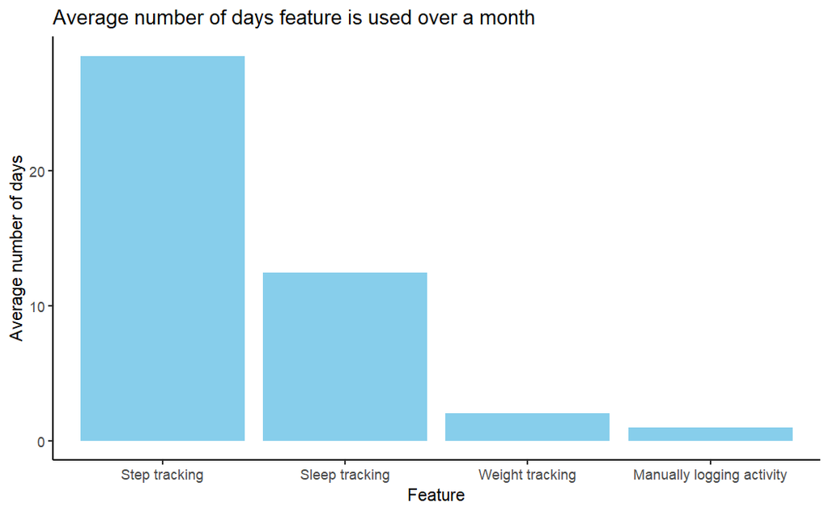

```r
mean_days_tracking_per_user <- days_tracking_per_user %>%
  pivot_longer(everything(), names_to = "X", values_to = "Y") %>%
  group_by(X) %>%
  summarise(Mean = mean(Y, na.rm=TRUE))

mean_days_tracking_per_user <- mean_days_tracking_per_user[-5,]
mean_days_tracking_per_user <- mean_days_tracking_per_user %>%
  mutate(X = recode(X, "days_logging_activity" = "Manually logging activity", "days_tracking_sleep" = "Sleep tracking", "days_tracking_steps" = "Step tracking", "days_tracking_weight" = "Weight tracking")) %>%
  arrange(Mean)

mean_days_tracking_per_user %>%
  ggplot(aes(x=reorder(X, -Mean), y=Mean)) +
  geom_col(fill="skyblue") +
  labs(title="Average number of days feature is used over a month", x="Feature", y="Average number of days") +
  theme_classic()
```

## Invesigating each variable over the month

```r
daily_all_clean <- subset(daily_all_clean, select= -c(weight_pounds_calc, weight_pounds_dif))
```

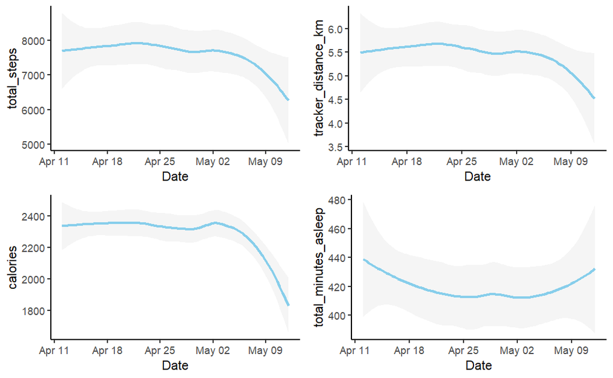

```r
col_names <- subset(daily_all_clean, select = c(total_steps, tracker_distance_km, calories, total_minutes_asleep))
col_names <- colnames(col_names)

my_plots_list <- lapply(col_names, function(i) {
  ggplot(daily_all_clean, aes_string(x=daily_all_clean$date, y=i)) +
    geom_smooth(color="skyblue", fill="grey90") +
    labs(x="Date") +
    theme_classic()
})

grid.arrange(grobs = my_plots_list, ncol=2)
```

#### Observations from line graphs:

- No clear pattern over the month for any variable
- Slight downward trend towards the end of the testing period for some variables - however this is likely to be due to testing period ending

## Investigating correlations between variables

Histogram shows at least one variable is not normally distributed, so spearman method used

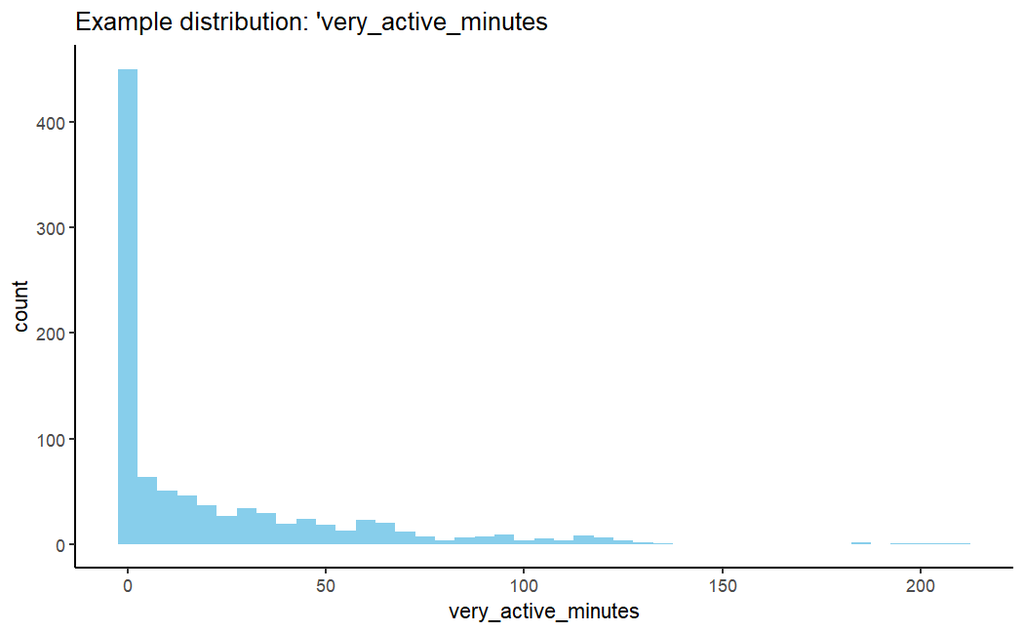

```r
ggplot(daily_all_clean, aes(very_active_minutes)) +
  geom_histogram(binwidth=5, fill="skyblue") +
  theme_classic() +
  labs(title="Example distribution: 'very_active_minutes")
```

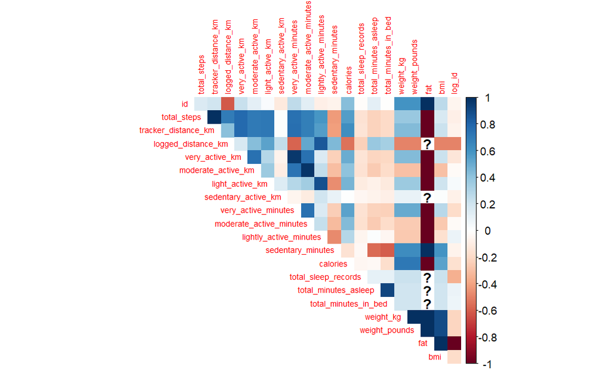

```r
cor_daily <- cor(num_only_daily, use="pairwise.complete.obs", method="spearman")
corrplot(cor_daily, method="color", diag=FALSE, type="upper", tl.cex = 0.6)
```

#### Observations from correlations:

- ‘Fat’ column disregarded due to insufficient records
- Expected correlations between steps, distance and activity levels
- No further correlations to investigate at this point
- Unexpected relationship between calories burnt and weight - this is likely due to limited data in weight fields

## Investigating steps over time

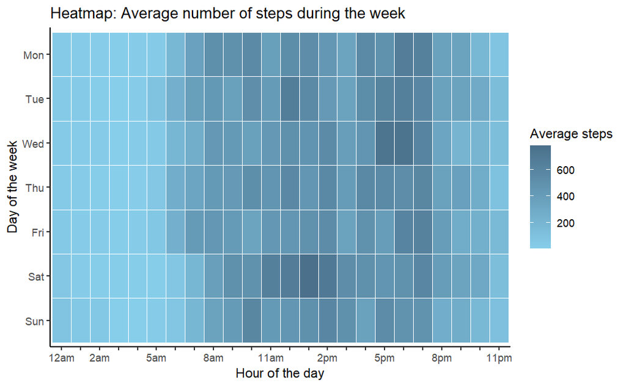

```r
hourly_merged$hour <- hour(hourly_merged$activity_hour)
hourly_merged$wday <- wday(hourly_merged$activity_hour, week_start=1)

steps_day_hour <- hourly_merged %>%
  group_by(hour, wday) %>%
  summarise(average_steps= mean(step_total))

steps_day_hour$wdayf <- factor(steps_day_hour$wday, levels=rev(1:7), labels=rev(c("Mon", "Tue", "Wed", "Thu", "Fri", "Sat", "Sun")))

steps_day_hour$hourf <- factor(steps_day_hour$hour, levels=as.character(0:23), labels=c("12am", "1am", "2am", "3am", "4am", "5am", "6am", "7am", "8am", "9am", "10am", "11am", "12pm", "1pm", "2pm", "3pm", "4pm", "5pm", "6pm", "7pm", "8pm", "9pm", "10pm", "11pm"))

ggplot(steps_day_hour, aes(hourf, wdayf, fill=average_steps)) +
  geom_tile(colour = "white") +
  scale_fill_gradient(low = "skyblue", high = "skyblue4") +
  theme_classic() +
  xlab("Hour of the day") +
  ylab("Day of the week") +
  ggtitle("Heatmap: Average number of steps during the week") +
  labs(fill="Average steps") +
  scale_x_discrete(guide=guide_axis(check.overlap=TRUE))
```

```r
NA
NA
```

#### Observations:

- Steps are higher during daytime hours (6am - 8pm)
- People become active later on the weekend (8am)
- Highest activity periods are weekday evenings (5pm - 8pm) and Saturday afternoons (11am - 2pm)
- These time periods can be used to target marketing strategies: time of day visuals should show to align with typical steps and time of day people are least active to target showing marketing adverts

## Read in dataframes for HR and steps by minute

```r
hr <- read_csv("C:/Users/katba/Data analysis learning/Portfolio/BellabeatCaseStudy/Fitabase Data 4.12.16-5.12.16/heartrate_seconds_merged.csv")
steps <- read_csv("C:/Users/katba/Data analysis learning/Portfolio/BellabeatCaseStudy/Fitabase Data 4.12.16-5.12.16/minuteStepsNarrow_merged.csv")
```

## Clean HR and steps to prepare for join

```r
hr <- clean_names(hr)
steps <- clean_names(steps)

steps$activity_minute <- as.POSIXct(steps$activity_minute, format="%m/%d/%Y %I:%M:%S %p")
hr$time <- as.POSIXct(hr$time, format="%m/%d/%Y %I:%M:%S %p")
```

```r
steps <- rename(steps, time = activity_minute)
```

#### Change HR to by minute

```r
hr_min <- hr %>%
  group_by(id, time = cut(time, breaks= "1 min")) %>%
  summarise(value= mean(value))
```

```r
glimpse(hr_min)
```

```
Rows: 333,420
Columns: 3
Groups: id [14]
$ id    <dbl> 2022484408, 2022484408, 2022484408, 2022484408, 2022484408, 2022484408, 2022484408, 2022484408, 2022484408, 2022484408, 2022484408, 2022484408, 2022484408, 2022484408, 2022484408, 2022484408, 2022484408, 20…
$ time  <fct> 2016-04-12 07:21:00, 2016-04-12 07:22:00, 2016-04-12 07:23:00, 2016-04-12 07:24:00, 2016-04-12 07:25:00, 2016-04-12 07:26:00, 2016-04-12 07:27:00, 2016-04-12 07:28:00, 2016-04-12 07:29:00, 2016-04-12 07:30:…
$ value <dbl> 101.60000, 87.88889, 58.00000, 58.00000, 56.77778, 53.16667, 55.14286, 65.66667, 73.00000, 78.00000, 71.83333, 81.77778, 84.50000, 78.42857, 85.77778, 90.22222, 93.14286, 88.00000, 85.12500, 85.16667, 85.00…
```

```r
hr_min$time <- as.character(hr_min$time)
hr_min$time <- as.POSIXct(hr_min$time, format="%Y-%m-%d %H:%M:%S")
```

## Join HR and steps

```r
hr_steps <- inner_join(hr_min, steps, by = c("id", "time"))
```

## Check distribution of variables in preparation for correlation

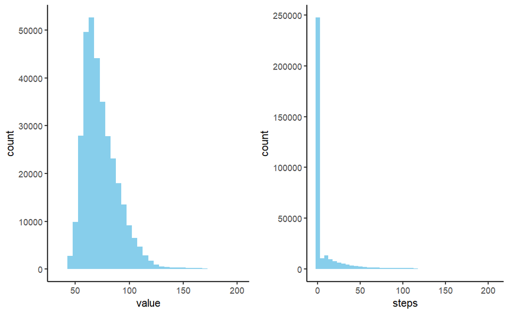

```r
ggarrange(
  ggplot(hr_steps, aes(value)) +
  geom_histogram(binwidth=5, fill="skyblue") +
    theme_classic(),
ggplot(hr_steps, aes(steps)) +
  geom_histogram(binwidth=5, fill="skyblue") +
  theme_classic()
)
```

```r
cor(hr_steps$value, hr_steps$steps, method="spearman")
```

```
[1] 0.558094
```

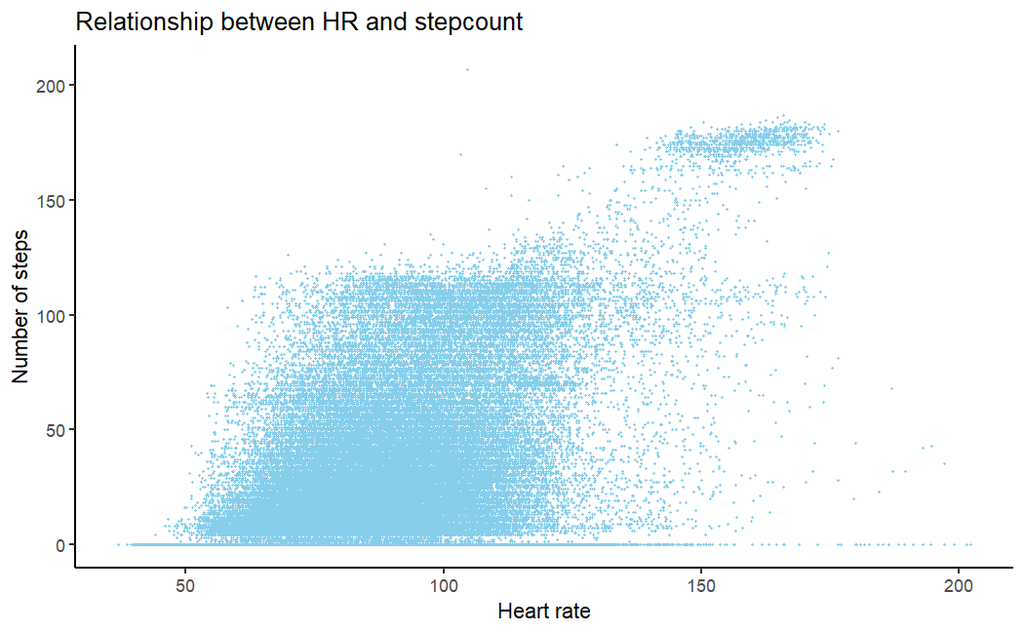

```r
ggplot(hr_steps, aes(value, steps)) +
  geom_point(color="skyblue", size=0.4) +
  theme_classic()+
  labs(title="Relationship between HR and stepcount", y="Number of steps", x="Heart rate")
```